# Experimental Design and Legacy Split-Plot Models

mixedFlowR tutorial series

# 1 Purpose

This vignette develops the design logic behind split-plot, split-split-plot, strip-plot, and repeated-measure experiments. It is deliberately placed before advanced mixed-model topics because the hierarchy of experimental units determines which model structures are scientifically defensible.

# 2 1. Learning objectives

You will learn to:

- distinguish observation, experimental unit, and sampling unit;
- identify whole-plot, subplot, and sub-subplot randomization levels;
- detect common forms of pseudoreplication;
- inspect design support and empty cells;
- understand expected mean-square logic in a classical split-plot;
- connect error strata to random effects in an LMM;
- understand when the classical balanced ANOVA becomes inadequate;
- recognize split-split and strip-plot structures.

# 3 2. Experimental units come before formulas

An **experimental unit** is the smallest unit that can independently receive a treatment under the randomization actually performed.

In a split-plot field trial, two treatment factors can have different experimental units.

| Level | Example | Randomized to | Consequence |
| --- | --- | --- | --- |
| block | field replicate | block | controls large-scale field variation |
| whole plot | variety / irrigation | large plot | whole-plot error for this factor |
| subplot | nitrogen / spray rate | subdivision | subplot residual for this factor |
| observation | yield sample | measured subplot | not automatically an independent replicate |

A formula does not create randomization. It represents randomization that already happened.

# 4 3. Inspect the split-plot dataset

```r
library(mixedFlowR)
d <- mixed_data("splitplot")
head(d)
```

```
#>   block variety nitrogen    yield
#> 1    B1      V1        0 53.92579
#> 2    B1      V1       50 62.24195
#> 3    B1      V1      100 69.33041
#> 4    B1      V1      150 71.76092
#> 5    B1      V2        0 59.14012
#> 6    B1      V2       50 63.76755
```

```r
with(d, table(block, variety))
```

```
#>      variety
#> block V1 V2 V3
#>    B1  4  4  4
#>    B2  4  4  4
#>    B3  4  4  4
#>    B4  4  4  4
#>    B5  4  4  4
#>    B6  4  4  4
```

```r
with(d, table(variety, nitrogen))
```

```
#>        nitrogen
#> variety 0 50 100 150
#>      V1 6  6   6   6
#>      V2 6  6   6   6
#>      V3 6  6   6   6
```

The number of rows is larger than the number of whole plots because several nitrogen subplots occur inside each block-by-variety whole plot.

# 5 4. Design audit and hierarchy

```r
audit <- mixed_design_audit(
  d,
  response = "yield",
  block    = "block",
  whole    = "variety",
  sub      = "nitrogen"
)
audit
```

```
#> $n
#> [1] 72
#>
#> $roles
#>   response      block      whole        sub
#>    "yield"    "block"  "variety" "nitrogen"
#>
#> $balance
#>    block variety nitrogen n
#> 1     B1      V1        0 1
#> 2     B2      V1        0 1
#> 3     B3      V1        0 1
#> 4     B4      V1        0 1
#> 5     B5      V1        0 1
#> 6     B6      V1        0 1
```

[output cut: 169 more lines]

```r
mixed_hierarchy(
  d,
  block = "block",
  whole = "variety",
  sub   = "nitrogen"
)
```

```
#> $roles
#>      block      whole        sub
#>    "block"  "variety" "nitrogen"
#>
#> $edges
#>    parent    child              relation
#> 1   block  variety declared nested/order
#> 2 variety nitrogen declared nested/order
```

```r
support <- mixed_balance(d, c("block", "variety", "nitrogen"))
support
```

```
#>    block variety nitrogen n
#> 1     B1      V1        0 1
#> 2     B2      V1        0 1
#> 3     B3      V1        0 1
#> 4     B4      V1        0 1
#> 5     B5      V1        0 1
#> 6     B6      V1        0 1
#> 7     B1      V2        0 1
#> 8     B2      V2        0 1
#> 9     B3      V2        0 1
#> 10    B4      V2        0 1
#> 11    B5      V2        0 1
#> 12    B6      V2        0 1
#> 13    B1      V3        0 1
#> 14    B2      V3        0 1
```

[output cut: 58 more lines]

## 5.1 What the audit can and cannot know

The software can inspect the declared columns and observed support. It cannot reconstruct undocumented field operations. If the whole-plot factor was physically applied at another scale, the analyst must provide that information.

# 6 5. Pseudoreplication: a practical diagnostic

Create the whole-plot identifier explicitly.

```r
d$whole_plot <- interaction(d$block, d$variety, drop = TRUE)
length(unique(d$whole_plot))
```

```
#> [1] 18
```

```r
nrow(d)
```

```
#> [1] 72
```

Screen treatment assignment at that cluster level.

```r
mixed_pseudorep(
  d,
  response  = "yield",
  cluster   = "whole_plot",
  treatment = "variety"
)
```

```
#> $cluster_declared
#> [1] TRUE
#>
#> $counts
#>    cluster treatment n
#> 1    B1.V1        V1 4
#> 2    B2.V1        V1 4
#> 3    B3.V1        V1 4
#> 4    B4.V1        V1 4
#> 5    B5.V1        V1 4
#> 6    B6.V1        V1 4
#> 25   B1.V2        V2 4
#> 26   B2.V2        V2 4
#> 27   B3.V2        V2 4
#> 28   B4.V2        V2 4
#> 29   B5.V2        V2 4
#> 30   B6.V2        V2 4
#> 49   B1.V3        V3 4
#> 50   B2.V3        V3 4
#> 51   B3.V3        V3 4
#> 52   B4.V3        V3 4
#> 53   B5.V3        V3 4
#> 54   B6.V3        V3 4
#>
#> $repeated_within_cluster
#> [1] TRUE
#>
#> $note
#> [1] "Repeated observations within a cluster require an analysis that preserves that dependence; repetition alone does not prove pseudoreplication."
```

A common error is to count every subplot as an independent replicate of variety. The true replication for variety is at the whole-plot level.

# 7 6. Classical split-plot decomposition

For a textbook classical ANOVA, represent nitrogen as a categorical subplot factor.

```r
d$nitrogen_f <- factor(d$nitrogen)
```

Fit the legacy analysis.

```r
legacy <- fit_legacy_splitplot(
  d,
  response = "yield",
  block    = "block",
  whole    = "variety",
  sub      = "nitrogen_f"
)
legacy
```

```
#>
#> Call:
#> stats::aov(formula = f, data = data)
#>
#> Grand Mean: 58.69065
#>
#> Stratum 1: block
#>
#> Terms:
#>                 Residuals
#> Sum of Squares   513.6647
#> Deg. of Freedom         5
#>
#> Residual standard error: 10.13573
#>
#> Stratum 2: block:variety
#>
#> Terms:
#>                  variety Residuals
#> Sum of Squares  758.6431  149.8528
#> Deg. of Freedom        2        10
#>
#> Residual standard error: 3.871083
#> 6 out of 8 effects not estimable
#> Estimated effects may be unbalanced
#>
#> Stratum 3: Within
#>
#> Terms:
#>                 nitrogen_f variety:nitrogen_f Residuals
#> Sum of Squares   2094.2151            18.5941  215.8678
#> Deg. of Freedom          3                  6        45
#>
#> Residual standard error: 2.19022
#> Estimated effects may be unbalanced
```

Extract the flattened ANOVA table.

```r
legacy_tab <- splitplot_anova(legacy)
legacy_tab
```

```
#>   Df     Sum Sq    Mean Sq     F value       Pr(>F)               term
#> 1  5  513.66467 102.732934          NA           NA          Residuals
#> 2  2  758.64310 379.321549  25.3129410 1.220983e-04          variety
#> 3 10  149.85282  14.985282          NA           NA          Residuals
#> 4  3 2094.21514 698.071714 145.5206532 3.572178e-23 nitrogen_f
#> 5  6   18.59409   3.099015   0.6460235 6.929144e-01 variety:nitrogen_f
#> 6 45  215.86783   4.797063          NA           NA Residuals
#>                stratum
#> 1         Error: block
#> 2 Error: block:variety
#> 3 Error: block:variety
#> 4        Error: Within
#> 5        Error: Within
#> 6        Error: Within
```

Display the expected mean-square teaching table.

```r
ems <- splitplot_ems(
  d,
  block = "block",
  whole = "variety",
  sub   = "nitrogen_f"
)
ems
```

```
#>              source df                           expected_mean_square
#> 1             Block  5 sigma_eB^2 + treatment-independent block terms
#> 2 Whole plot factor  2       sigma_eB^2 + whole-plot treatment signal
#> 3  Whole-plot error 10        sigma_eB^2 (block x whole-plot stratum)
#> 4    Subplot factor  3           sigma_e^2 + subplot treatment signal
#> 5       Whole x Sub  6                 sigma_e^2 + interaction signal
#> 6     Subplot error 45                                      sigma_e^2
#>        denominator
#> 1             <NA>
#> 2 Whole-plot error
#> 3             <NA>
#> 4    Subplot error
#> 5    Subplot error
#> 6             <NA>
```

# 8 7. How to read the error strata

For a balanced split-plot, the conceptual rule is:

- whole-plot factor: tested against variation among whole plots within blocks;
- subplot factor: tested against subplot residual variation;
- whole-by-sub interaction: also uses subplot-level variation in the classical decomposition.

This is why ordinary two-way ANOVA is not a valid substitute for split-plot ANOVA.

# 9 8. Transition to a mixed model

```r
if (requireNamespace("lme4", quietly = TRUE)) {
  fit_factor <- mixed_fit(
    yield ~ variety * nitrogen_f +
      (1 | block) +
      (1 | block:variety),
    data = d
  )

  fit_factor
}
```

```
#> $call
#> mixed_fit(formula = yield ~ variety * nitrogen_f + (1 | block) +
#>     (1 | block:variety), data = d)
#>
#> $engine
#> [1] "lme4"
#>
#> $model
#> Linear mixed model fit by REML ['lmerMod']
#> Formula: yield ~ variety * nitrogen_f + (1 | block) + (1 | block:variety)
#>    Data: ..mf_data
#> REML criterion at convergence: 312.5653
#> Random effects:
#>  Groups        Name        Std.Dev.
#>  block:variety (Intercept) 1.596
#>  block         (Intercept) 2.704
#>  Residual                  2.190
#> Number of obs: 72, groups:  block:variety, 18; block, 6
#> Fixed Effects:
#>             (Intercept)                varietyV2                varietyV3
#>                 49.4576                   5.1434                  -2.2778
#>            nitrogen_f50            nitrogen_f100            nitrogen_f150
#>                  7.2617                  12.0789                  14.7597
#>  varietyV2:nitrogen_f50   varietyV3:nitrogen_f50  varietyV2:nitrogen_f100
#>                 -0.3546                   0.3513                   0.4568
#> varietyV3:nitrogen_f100  varietyV2:nitrogen_f150  varietyV3:nitrogen_f150
#>                 -1.9355                  -0.7160                  -0.7687
#>
#> $data
#>    block variety nitrogen    yield whole_plot nitrogen_f
#> 1     B1      V1        0 53.92579      B1.V1          0
#> 2     B1      V1       50 62.24195      B1.V1         50
#> 3     B1      V1      100 69.33041      B1.V1        100
#> 4     B1      V1      150 71.76092      B1.V1        150
#> 5     B1      V2        0 59.14012      B1.V2          0
#> 6     B1      V2       50 63.76755      B1.V2         50
#> 7     B1      V2      100 70.00531      B1.V2        100
#> 8     B1      V2      150 74.42650      B1.V2        150
#> 9     B1      V3        0 50.05311      B1.V3          0
#> 10    B1      V3       50 56.00415      B1.V3         50
```

[output cut: 78 more lines]

```
#>
#>
#> $warnings
#> character(0)
#>
#> $audit
#> $audit$timestamp
#> [1] "2026-08-18 23:52:33.502355"
#>
#> $audit$engine
#> [1] "lme4"
#>
#>
#> attr(,"class")
#> [1] "mixedflow_fit"
```

The model can be read as:

- fixed population effects for variety, nitrogen, and their interaction;
- random block-to-block variation;
- random whole-plot variation through block-by-variety;
- subplot residual variation.

Compare directly.

```r
if (requireNamespace("lme4", quietly = TRUE)) {
  compare_legacy_mixed(
    d,
    "yield",
    "block",
    "variety",
    "nitrogen_f"
  )
}
```

```
#> $legacy
#>
#> Call:
#> stats::aov(formula = f, data = data)
#>
#> Grand Mean: 58.69065
#>
#> Stratum 1: block
#>
#> Terms:
#>                 Residuals
#> Sum of Squares   513.6647
#> Deg. of Freedom         5
#>
#> Residual standard error: 10.13573
#>
#> Stratum 2: block:variety
#>
#> Terms:
#>                  variety Residuals
#> Sum of Squares  758.6431  149.8528
#> Deg. of Freedom        2        10
#>
#> Residual standard error: 3.871083
#> 6 out of 8 effects not estimable
#> Estimated effects may be unbalanced
#>
#> Stratum 3: Within
#>
#> Terms:
#>                 nitrogen_f variety:nitrogen_f Residuals
#> Sum of Squares   2094.2151            18.5941  215.8678
#> Deg. of Freedom          3                  6        45
#>
#> Residual standard error: 2.19022
#> Estimated effects may be unbalanced
#>
#> $mixed
#> $call
#> NULL
```

[output cut: 143 more lines]

```
#> 4             nitrogen_f50  7.2617342  1.264520
#> 5            nitrogen_f100 12.0789470  1.264520
#> 6            nitrogen_f150 14.7596861  1.264520
#> 7   varietyV2:nitrogen_f50 -0.3546374  1.788302
#> 8   varietyV3:nitrogen_f50  0.3512835  1.788302
#> 9  varietyV2:nitrogen_f100  0.4567622  1.788302
#> 10 varietyV3:nitrogen_f100 -1.9354814  1.788302
#> 11 varietyV2:nitrogen_f150 -0.7159760  1.788302
#> 12 varietyV3:nitrogen_f150 -0.7686759  1.788302
#>
#> $variance
#>             grp        var1 var2     vcov    sdcor
#> 1 block:variety (Intercept) <NA> 2.547064 1.595952
#> 2         block (Intercept) <NA> 7.312720 2.704204
#> 3      Residual        <NA> <NA> 4.797036 2.190214
```

**Interpretation.** Close agreement is expected only when the parameterizations and balanced-design assumptions are comparable. The point is to validate the randomization logic, not to force exact equality of every summary statistic under different inferential conventions.

# 10 9. Quantitative subplot treatment: a different question

A classical factor ANOVA asks whether dose levels differ. A regression-oriented mixed model asks how yield changes along a quantitative nitrogen scale.

```r
if (requireNamespace("lme4", quietly = TRUE)) {
  fit_numeric <- mixed_fit(
    yield ~ variety * poly(nitrogen, 2) +
      (1 | block) +
      (1 | block:variety),
    data = d
  )
}
```

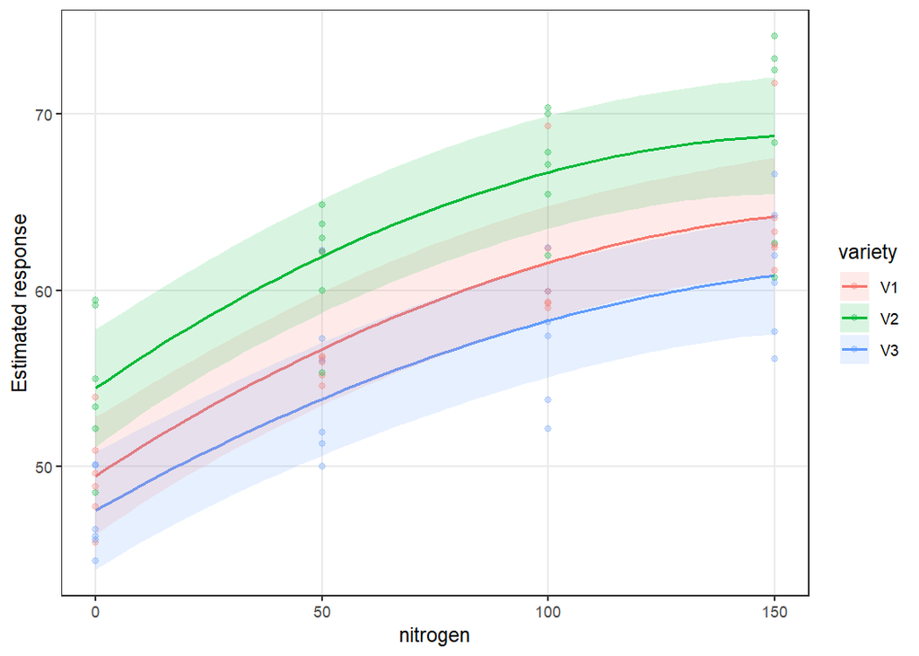

```r
if (
  exists("fit_numeric") &&
  requireNamespace("emmeans", quietly = TRUE)
) {
  mixed_plot(
    fit_numeric,
    type      = "curve",
    x         = "nitrogen",
    by        = "variety",
    values    = seq(min(d$nitrogen), max(d$nitrogen), length.out = 61),
    show_data = TRUE
  )
}
```

This approach is often more useful when dose has a mechanistic or agronomic continuum.

# 11 10. Deliberately create an incomplete design

Remove one subplot observation.

```r
d_incomplete <- d[-1, ]
mixed_balance(d_incomplete, c("block", "variety", "nitrogen"))
```

```
#>    block variety nitrogen n
#> 1     B2      V1        0 1
#> 2     B3      V1        0 1
#> 3     B4      V1        0 1
#> 4     B5      V1        0 1
#> 5     B6      V1        0 1
#> 6     B1      V2        0 1
#> 7     B2      V2        0 1
#> 8     B3      V2        0 1
#> 9     B4      V2        0 1
#> 10    B5      V2        0 1
#> 11    B6      V2        0 1
#> 12    B1      V3        0 1
#> 13    B2      V3        0 1
#> 14    B3      V3        0 1
```

[output cut: 58 more lines]

The classical balanced decomposition is now less attractive. A mixed model can accommodate missing observations under its likelihood assumptions, but the missingness mechanism and reduced information must still be considered.

# 12 11. Split-split-plot design

A split-split plot introduces a third randomization scale. To illustrate the API, construct a teaching factor `stage`. This is only a software demonstration; a real split-split factor must come from genuine randomization.

```r
d_ss <- d
d_ss$stage <- factor(rep(c("S1", "S2"), length.out = nrow(d_ss)))
```

```r
ss <- fit_legacy_splitsplit(
  d_ss,
  response = "yield",
  block    = "block",
  whole    = "variety",
  sub      = "nitrogen_f",
  subsub   = "stage"
)
ss
```

```
#>
#> Call:
#> stats::aov(formula = f, data = data)
#>
#> Grand Mean: 58.69065
#>
#> Stratum 1: block
#>
#> Terms:
#>                 Residuals
#> Sum of Squares   513.6647
#> Deg. of Freedom         5
#>
#> Residual standard error: 10.13573
#>
#> Stratum 2: block:variety
#>
#> Terms:
#>                  variety Residuals
#> Sum of Squares  758.6431  149.8528
#> Deg. of Freedom        2        10
#>
#> Residual standard error: 3.871083
#> 12 out of 14 effects not estimable
#> Estimated effects may be unbalanced
#>
#> Stratum 3: block:variety:nitrogen_f
#>
#> Terms:
#>                 nitrogen_f variety:nitrogen_f Residuals
#> Sum of Squares   2094.2151            18.5941  215.8678
#> Deg. of Freedom          3                  6        45
#>
#> Residual standard error: 2.19022
#> 9 out of 18 effects not estimable
#> Estimated effects may be unbalanced
```

**Important.** Never manufacture a sub-subplot factor in a real analysis just to fit a more complex model. The code above is strictly a syntax demonstration.

# 13 12. Strip-plot design

Strip plots arise when two factors are randomized in perpendicular or intersecting strips, creating distinct error terms for each strip factor and their intersection.

For API demonstration:

```r
d_strip <- d
d_strip$A <- factor(d_strip$variety)
d_strip$B <- factor(d_strip$nitrogen)
```

```r
strip <- fit_legacy_stripplot(
  d_strip,
  response = "yield",
  block    = "block",
  strip_a  = "A",
  strip_b  = "B"
)
strip
```

```
#>
#> Call:
#> stats::aov(formula = f, data = data)
#>
#> Grand Mean: 58.69065
#>
#> Stratum 1: block
#>
#> Terms:
#>                 Residuals
#> Sum of Squares   513.6647
#> Deg. of Freedom         5
#>
#> Residual standard error: 10.13573
#>
#> Stratum 2: block:A
#>
#> Terms:
#>                        A Residuals
#> Sum of Squares  758.6431  149.8528
#> Deg. of Freedom        2        10
#>
#> Residual standard error: 3.871083
#> 6 out of 8 effects not estimable
#> Estimated effects may be unbalanced
#>
#> Stratum 3: block:B
#>
#> Terms:
#>                         B Residuals
#> Sum of Squares  2094.2151   73.7661
#> Deg. of Freedom         3        15
#>
#> Residual standard error: 2.217597
#> 6 out of 9 effects not estimable
#> Estimated effects may be unbalanced
#>
#> Stratum 4: Within
#>
#> Terms:
#>                       A:B Residuals
#> Sum of Squares   18.59409 142.10175
#> Deg. of Freedom         6        30
#>
#> Residual standard error: 2.176402
#> Estimated effects may be unbalanced
```

A true strip-plot analysis requires the field layout to satisfy this randomization structure.

# 14 13. Repeated measures are not automatically split plots

Repeated measurements share the same observational unit over time. They create within-unit dependence. Sometimes repeated measures occur inside a split-plot experiment, but the two structures should not be conflated.

```r
z <- mixed_data("longitudinal")
head(z)
```

```
#>   subject treatment time   height
#> 1     S01        T1    0 17.27455
#> 2     S01        T1    1 17.38720
#> 3     S01        T1    2 20.55889
#> 4     S01        T1    3 24.15167
#> 5     S01        T1    4 26.40212
#> 6     S01        T1    5 29.13063
```

The repeated subject can be declared in a design audit.

```r
mixed_design_audit(
  z,
  response = "height",
  subject  = "subject",
  time     = "time"
)
```

```
#> $n
#> [1] 180
#>
#> $roles
#>  response   subject      time
#>  "height" "subject"    "time"
#>
#> $balance
#>     subject time n
#> 1       S01    0 1
#> 2       S02    0 1
#> 3       S03    0 1
#> 4       S04    0 1
#> 5       S05    0 1
#> 6       S06    0 1
```

[output cut: 234 more lines]

Later, `mixed_ar1()`, `mixed_car1()`, and `mixed_heterogeneity()` will model residual dependence that remains after the fixed and random effects.

# 15 14. Three common design failures

## 15.1 Failure 1: wrong replication count

**Mistake:** treating subplots as independent variety replicates.

**Consequence:** standard errors for the whole-plot factor can be severely underestimated.

**Prevention:** explicitly define the whole plot and random structure.

## 15.2 Failure 2: random effect chosen from software convention

**Mistake:** adding `(1|block)` because it is common, while omitting the whole-plot experimental unit.

**Consequence:** the model may not represent the randomization.

**Prevention:** derive grouping factors from field operations.

## 15.3 Failure 3: changing a quantitative factor to categorical only to obtain letters

**Mistake:** reducing a dose-response question to many pairwise tests.

**Consequence:** loss of shape information and potentially lower power.

**Prevention:** use `mixed_trend()`, `mixed_curve()`, and `mixed_optimum()` when the quantitative scale is meaningful.

# 16 15. Reporting a split-plot analysis

A methods section should report at least:

1. block structure and number of blocks;
2. whole-plot experimental unit;
3. subplot experimental unit;
4. treatment allocation and randomization;
5. whether subplot treatment was modeled categorically or quantitatively;
6. random-effects structure;
7. estimation method;
8. denominator-DF approach for fixed-effect tests when used;
9. diagnostics and any sensitivity analysis;
10. estimates with uncertainty.

# 17 16. Practice exercise: from wrong to correct

Fit the intentionally incomplete model below and compare its random-effect structure with the design-correct model.

```r
if (requireNamespace("lme4", quietly = TRUE)) {
  wrong <- mixed_fit(
    yield ~ variety * nitrogen_f + (1 | block),
    data = d
  )

  correct <- mixed_fit(
    yield ~ variety * nitrogen_f +
      (1 | block) +
      (1 | block:variety),
    data = d
  )
}
```

Do not decide between them only from AIC. Explain which randomization level is missing from `wrong`.

# 18 17. Key take-home messages

- Experimental-unit hierarchy is a property of the experiment, not the software.
- Whole-plot and subplot treatments have different error scales.
- Legacy ANOVA is highly valuable for teaching and balanced-design auditing.
- Mixed models generalize the representation but do not remove the need to understand randomization.
- Quantitative subplot treatments deserve regression-oriented interpretation when scientifically appropriate.

# 19 18. Next vignette

Continue with `03-random-effects-and-shrinkage.Rmd` to understand the statistical meaning of random intercepts, random slopes, nesting, crossing, BLUPs, and partial pooling.